# Stats 110 Homework 5

Owen Lin

11/29/2022

1. 1. You can’t randomly assign an ethnic group to a mother and then observe baby’s weight. It can only be an observational study and thus omitted variable bias exist. For instant, it could be that mother from the same ethnic groups share a food preference shaped by the culture, which affect the birth weight of infants.
   2. We can not extend our sample’s results to all US births because a random (representative) sample in North Carolina is not necessarily a representative sample of the US.
2. 1. See Output

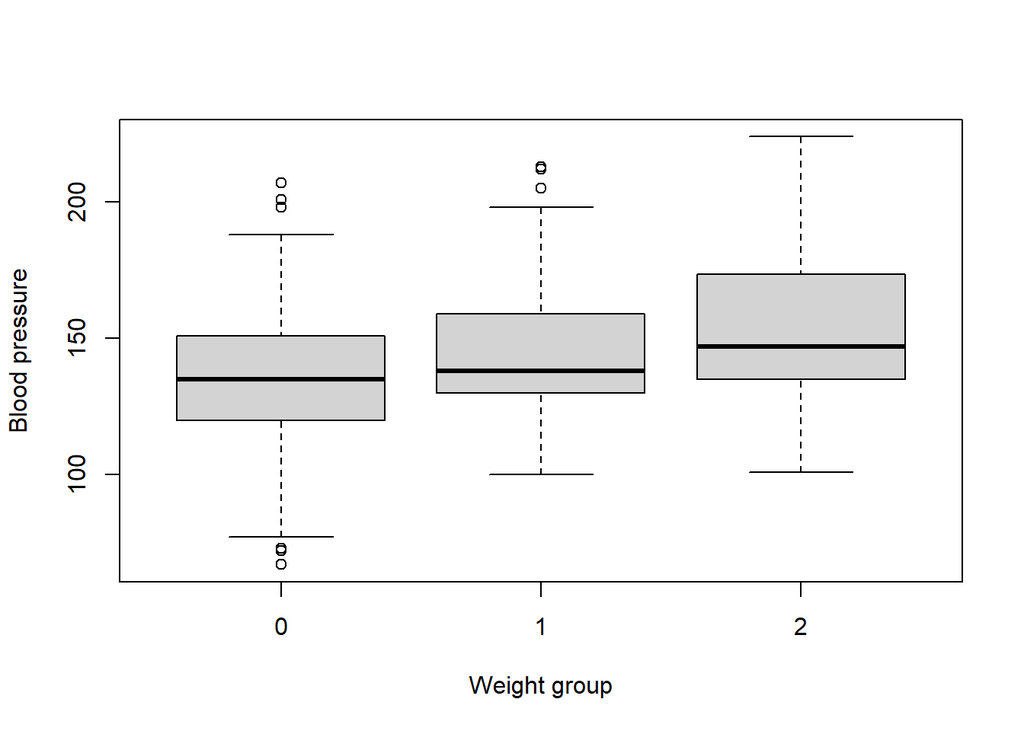

```r
blood <- read.table("Blood.txt", fill = TRUE, header = TRUE)
blood$Overwt <- as.factor(blood$Overwt)
blood$Smoke <- as.factor(blood$Smoke)
boxplot(blood$SystolicBP ~ blood$Overwt, ylab = "Blood pressure", xlab = "Weight group")
```

2. Weight group 0 : mean = 136.31, sd = 27.26, size = 187  
   Weight group 1 : mean = 144.36, sd = 25.07, size = 109  
   Weight group 2 : mean = 153.18, sd = 27.81, size = 204

```r
tapply(blood$SystolicBP, blood$Overwt, mean)
tapply(blood$SystolicBP, blood$Overwt, sd)
tapply(blood$SystolicBP, blood$Overwt, length)
```

```
##        0        1        2
## 136.3155 144.3670 153.1814
##        0        1        2
## 27.26852 25.07864 27.81397
##   0   1   2
## 187 109 204
```

```r
ano2f <- aov(SystolicBP ~ Overwt, data = blood)
summary(ano2f)
```

```
##              Df Sum Sq Mean Sq F value  Pr(>F)
## Overwt        2  27801   13900   19.02 1.1e-08 ***
## Residuals   497 363274     731
## ---
## Signif. codes:  0 '***' 0.001 '**' 0.01 '*' 0.05 '.' 0.1 ' ' 1
```

7. It seems like weight group 2 is significantly different than both 1 and 0 at 95% confidence

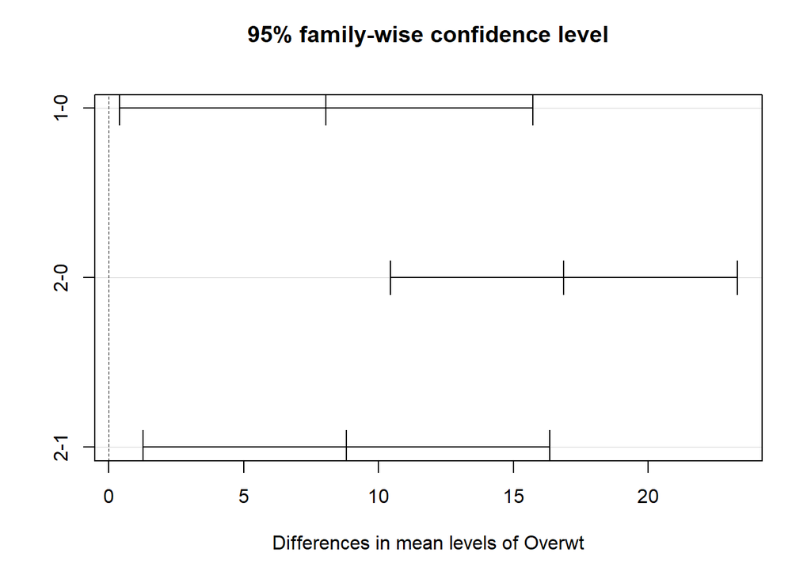

```
##   Tukey multiple comparisons of means
##     95% family-wise confidence level
##     factor levels have been ordered
##
## Fit: aov(formula = SystolicBP ~ Overwt, data = blood)
##
## $Overwt
##          diff        lwr      upr     p adj
## 1-0  8.051464  0.3927115 15.71022 0.0366867
## 2-0 16.865865 10.4316024 23.30013 0.0000000
## 2-1  8.814400  1.2740746 16.35473 0.0170703
```

```r
TukeyHSD(ano2f, ordered = T)
plot(TukeyHSD(ano2f, ordered = T))
```

8. $SystolicBP_i = \mu + \alpha_k + \beta_j + \epsilon_{i,k,j}$, k = 0, 1, 2; j = 0, 1
9. See Output.

```r
ano2h <- aov(SystolicBP ~ Overwt + Smoke, data = blood)
summary(ano2h)
```

```
##              Df Sum Sq Mean Sq F value   Pr(>F)
## Overwt        2  27801   13900   19.53 6.84e-09 ***
## Smoke         1  10277   10277   14.44 0.000163 ***
## Residuals   496 352997     712
## ---
## Signif. codes:  0 '***' 0.001 '**' 0.01 '*' 0.05 '.' 0.1 ' ' 1
```

```r
ano2l <- aov(SystolicBP ~ Overwt + Smoke + Overwt*Smoke, data = blood)
# summary(ano2l)
```

[output not shown]

3. 1. Response variable: amount eaten  
      First factor: Male or Female  
      Second factor: leptin or insulin injection
   2. First factor: Observational with 2 levels  
      Second factor: experimental with 2 levels
   3. The results indicate that there is an interaction between the two factors in their effect on the response, because the affect of second factor is different base on gender.
4. 1. Response variable: score on the set of math problems  
      First factor: hyperactive or not  
      Second factor: high noise and low noise
   2. First factor: Observational with 2 levels  
      Second factor: experimental with 2 levels
   3. The results indicate that there is an interaction between the two factors in their effect on the response, because the performance under high noise and low noise is different base on the level of first factor.
5. 1. $\mu$ = (12+17+14+16)/4 = 14.75
   2. $\alpha_1$ = (12+17)/2 - 14.75 = -0.25  
      $\alpha_2$ = (14+16)/2 - 14.75 = 0.25
   3. $\beta_1$ = (12+14)/2 - 14.75 = -1.75  
      $\beta_2$ = (17+16)/2 - 14.75 = 1.75
   4. $\gamma_{11}$ = 12 - 14.75 - (-0.25 + -1.75) = -0.75  
      $\gamma_{12}$ = 17 - 14.75 - (-0.25 + 1.75) = 0.75  
      $\gamma_{21}$ = 14 - 14.75 - (0.25 + -1.75) = 0.75  
      $\gamma_{22}$ = 16 - 14.75 - (0.25 + 1.75) = -0.75
6. K=2, J=2, n=25 (N = 100)

```r
table <- data.frame(Source = c('Face', 'Gender', 'Interaction', 'Residual', 'Total'), df = c(1, 1, 1, 96, 99), SS = c(12915, 2500, 400, 9600, 25415), MS = c(12915, 2500, 400, 100, 15915), F = c(129.15, 25, 4, NA, NA))

table
```

```
##        Source df    SS    MS      F
## 1        Face  1 12915 12915 129.15
## 2      Gender  1  2500  2500  25.00
## 3 Interaction  1   400   400   4.00
## 4    Residual 96  9600   100     NA
## 5       Total 99 25415 15915     NA
```